# Red Wine Analysis By : Shruti Rawat

```
## [1] "E:/DATA ANALYTICS/PROJECT2"
```

```
##  [1] "X"                    "fixed.acidity"        "volatile.acidity"
##  [4] "citric.acid"          "residual.sugar"       "chlorides"
##  [7] "free.sulfur.dioxide"  "total.sulfur.dioxide" "density"
## [10] "pH"                   "sulphates"            "alcohol"
## [13] "quality"
```

# UNIVARIATE PLOTS SECTION

```
## 'data.frame':    1599 obs. of  13 variables:
##  $ X                   : int  1 2 3 4 5 6 7 8 9 10 ...
##  $ fixed.acidity       : num  7.4 7.8 7.8 11.2 7.4 7.4 7.9 7.3 7.8 7.5 ...
##  $ volatile.acidity    : num  0.7 0.88 0.76 0.28 0.7 0.66 0.6 0.65 0.58 0.5 ...
##  $ citric.acid         : num  0 0 0.04 0.56 0 0 0.06 0 0.02 0.36 ...
##  $ residual.sugar      : num  1.9 2.6 2.3 1.9 1.9 1.8 1.6 1.2 2 6.1 ...
##  $ chlorides           : num  0.076 0.098 0.092 0.075 0.076 0.075 0.069 0.065 0.073 0.071 ...
##  $ free.sulfur.dioxide : num  11 25 15 17 11 13 15 15 9 17 ...
##  $ total.sulfur.dioxide: num  34 67 54 60 34 40 59 21 18 102 ...
##  $ density             : num  0.998 0.997 0.997 0.998 0.998 ...
##  $ pH                  : num  3.51 3.2 3.26 3.16 3.51 3.51 3.3 3.39 3.36 3.35 ...
##  $ sulphates           : num  0.56 0.68 0.65 0.58 0.56 0.56 0.46 0.47 0.57 0.8 ...
##  $ alcohol             : num  9.4 9.8 9.8 9.8 9.4 9.4 9.4 10 9.5 10.5 ...
##  $ quality             : int  5 5 5 6 5 5 5 7 7 5 ...
```

```
##        X          fixed.acidity   volatile.acidity  citric.acid
##  Min.   :   1.0   Min.   : 4.60   Min.   :0.1200   Min.   :0.000
##  1st Qu.: 400.5   1st Qu.: 7.10   1st Qu.:0.3900   1st Qu.:0.090
##  Median : 800.0   Median : 7.90   Median :0.5200   Median :0.260
##  Mean   : 800.0   Mean   : 8.32   Mean   :0.5278   Mean   :0.271
##  3rd Qu.:1199.5   3rd Qu.: 9.20   3rd Qu.:0.6400   3rd Qu.:0.420
##  Max.   :1599.0   Max.   :15.90   Max.   :1.5800   Max.   :1.000
##  residual.sugar     chlorides       free.sulfur.dioxide
##  Min.   : 0.900   Min.   :0.01200   Min.   : 1.00
##  1st Qu.: 1.900   1st Qu.:0.07000   1st Qu.: 7.00
##  Median : 2.200   Median :0.07900   Median :14.00
##  Mean   : 2.539   Mean   :0.08747   Mean   :15.87
##  3rd Qu.: 2.600   3rd Qu.:0.09000   3rd Qu.:21.00
##  Max.   :15.500   Max.   :0.61100   Max.   :72.00
##  total.sulfur.dioxide    density             pH          sulphates
##  Min.   :  6.00       Min.   :0.9901   Min.   :2.740   Min.   :0.3300
##  1st Qu.: 22.00       1st Qu.:0.9956   1st Qu.:3.210   1st Qu.:0.5500
##  Median : 38.00       Median :0.9968   Median :3.310   Median :0.6200
##  Mean   : 46.47       Mean   :0.9967   Mean   :3.311   Mean   :0.6581
##  3rd Qu.: 62.00       3rd Qu.:0.9978   3rd Qu.:3.400   3rd Qu.:0.7300
##  Max.   :289.00       Max.   :1.0037   Max.   :4.010   Max.   :2.0000
##     alcohol         quality
##  Min.   : 8.40   Min.   :3.000
##  1st Qu.: 9.50   1st Qu.:5.000
##  Median :10.20   Median :6.000
##  Mean   :10.42   Mean   :5.636
##  3rd Qu.:11.10   3rd Qu.:6.000
##  Max.   :14.90   Max.   :8.000
```

Our data set contains 1599 observations and 13 variables.

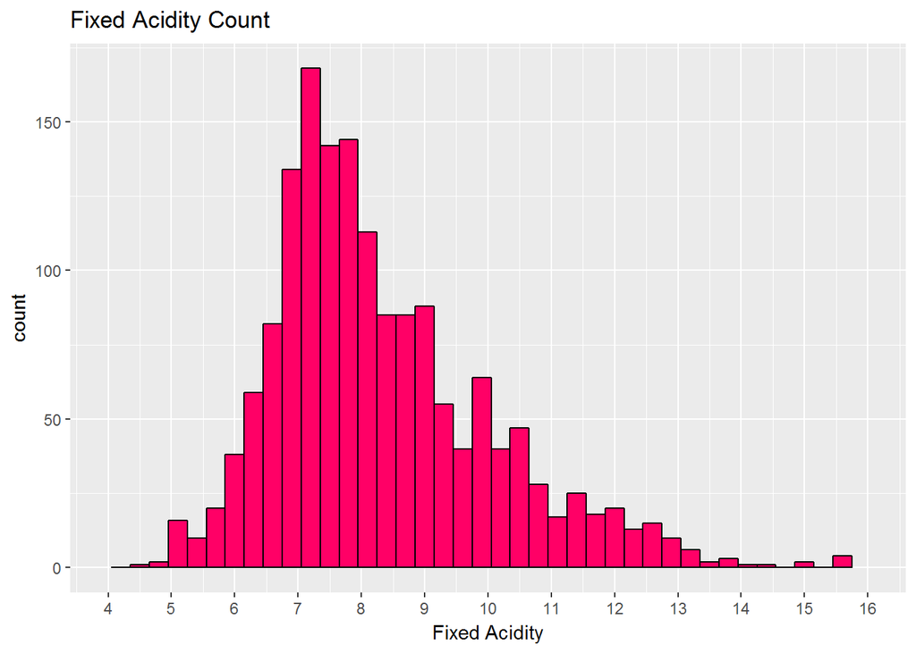

```r
ggplot(aes(x=fixed.acidity),data=pr)+
  geom_histogram(binwidth=0.3,color=I('black'),fill=I('#ff0066'))+
  scale_x_continuous(limits=c(4,16),breaks=seq(4,16,1))+
  xlab('Fixed Acidity')+
  ggtitle('Fixed Acidity Count')
```

Fixed Acidity is a long tailed histogram plot which has a Median of 7.90 and Mean of 8.32.

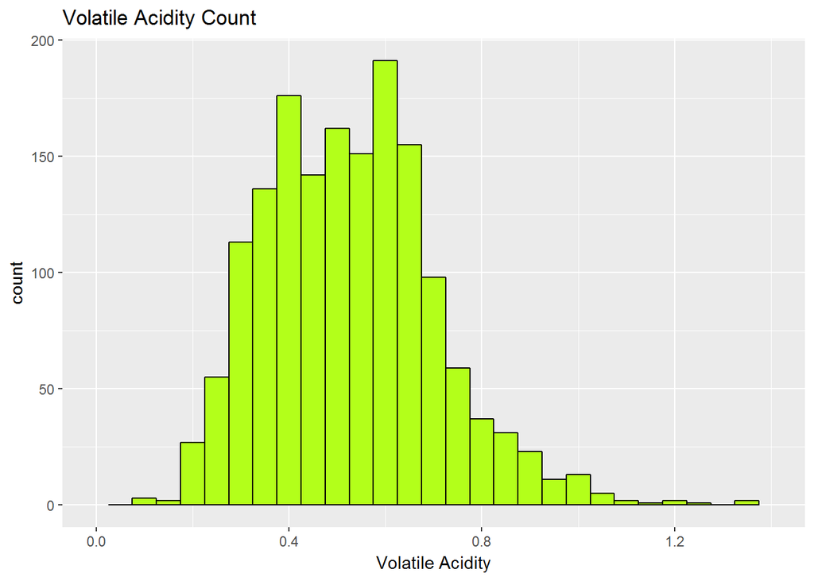

```r
ggplot(aes(x=volatile.acidity),data=pr)+
  geom_histogram(binwidth=0.05,color=I('black'),fill=I('#b3ff1a'))+
  scale_x_continuous(limits=c(0,1.4),breaks=seq(0,1.4,0.4))+
  xlab('Volatile Acidity')+
  ggtitle('Volatile Acidity Count')
```

Volatile Acidity is a normal histogram plot as well as long tailed that has a Median of 0.5200 and Mean of 0.5278.

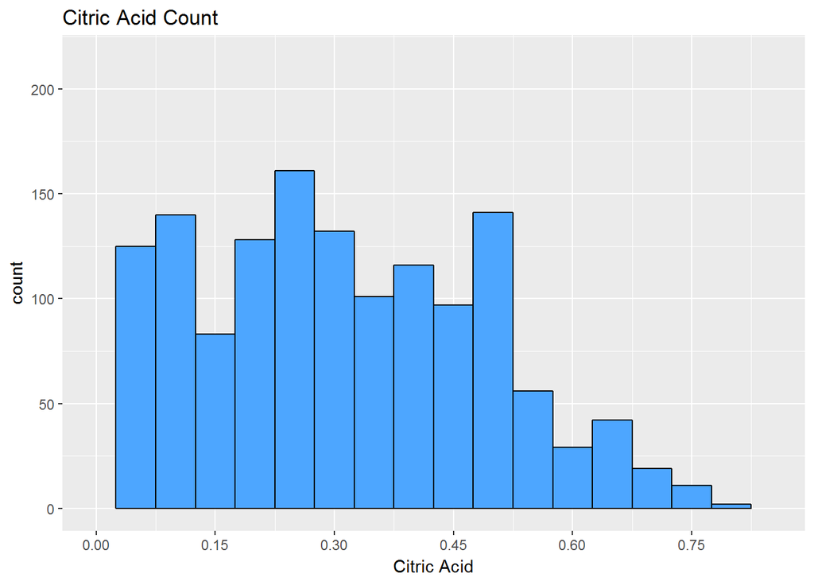

```r
ggplot(aes(x=citric.acid),data=pr)+
  geom_histogram(binwidth=0.05,color=I('black'),fill=I('#4da6ff'))+
  scale_x_continuous(limits=c(0,0.85),breaks=seq(0,0.85,0.15))+
  xlab('Citric Acid')+
  ggtitle('Citric Acid Count')
```

Citric Acid has a Median of 0.260 and Mean of 0.271.

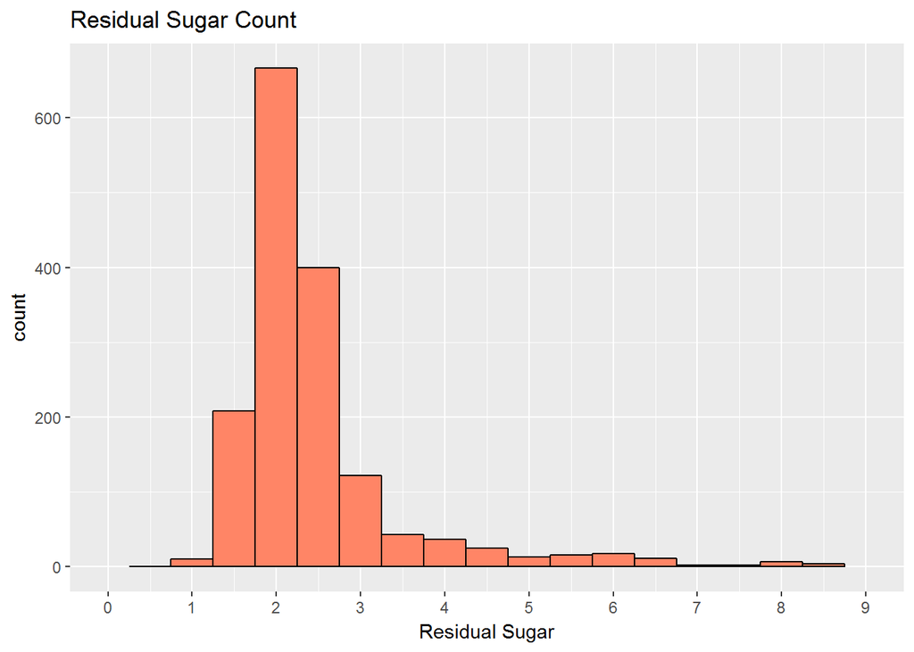

```r
ggplot(aes(x=residual.sugar),data=pr)+
  geom_histogram(binwidth=0.5,color=I('black'),fill=I('#ff8566'))+
  scale_x_continuous(limits=c(0,9),breaks=seq(0,9,1))+
  xlab('Residual Sugar')+
  ggtitle('Residual Sugar Count')
```

Residual Sugar has a long tailed histogram plot with a Median of 2.200 and Mean of 2.539.

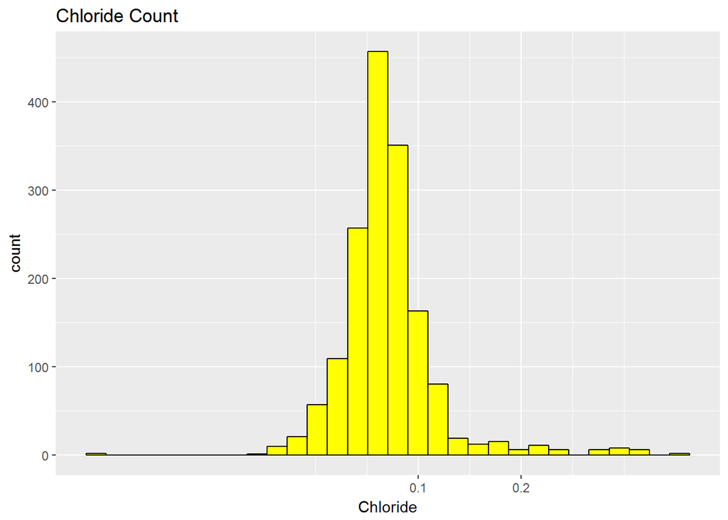

```r
ggplot(aes(x=chlorides),data=pr)+
  geom_histogram(color=I('black'),fill=I('#ffff00'))+
  scale_x_log10(breaks=seq(0,0.2,0.1))+
  xlab('Chloride')+
  ggtitle('Chloride Count')
```

Chlorides have a long tailed histogram plot with a Median of 0.07900 and Mean of 0.08747.

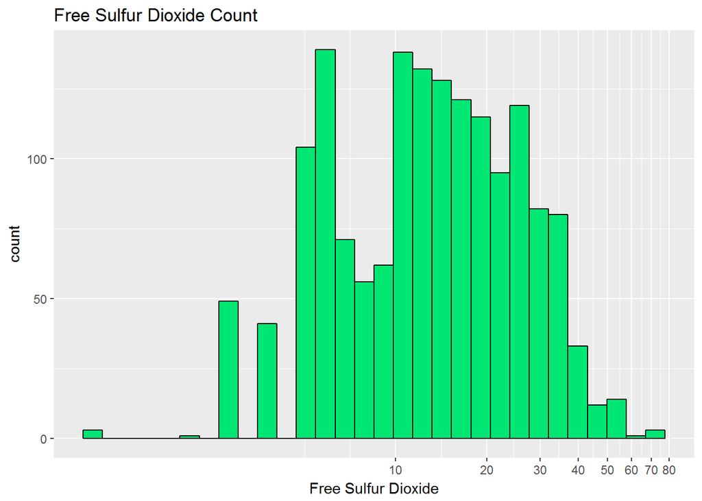

```r
ggplot(aes(x=free.sulfur.dioxide),data=pr)+
  geom_histogram(color=I('black'),fill=I('#00e673'))+
  #scale_x_continuous(limits=c(0,80),breaks=seq(0,80,10))+
  scale_x_log10(breaks=seq(0,80,10))+
  xlab('Free Sulfur Dioxide')+
  ggtitle('Free Sulfur Dioxide Count')
```

Free Sulphur Dioxide has a Median of 14.00 and Mean of 15.87.

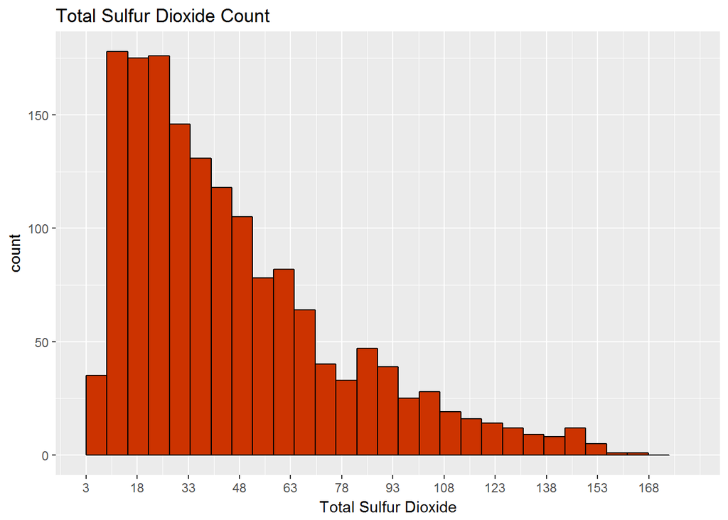

Total Sulfur Dioxide has a Median of 38.00 and Mean of 46.47.

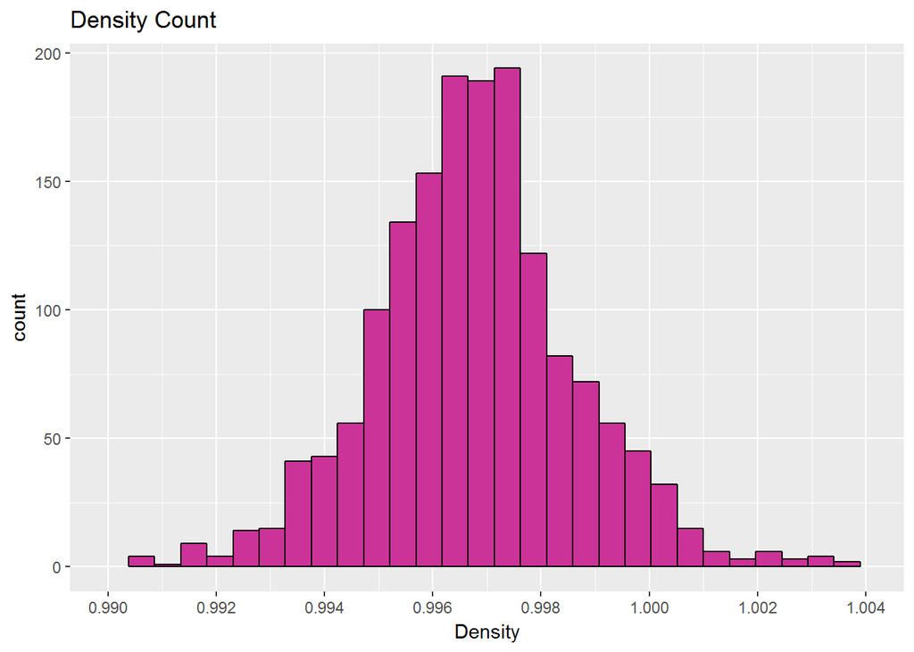

```r
ggplot(aes(x=density),data=pr)+
  geom_histogram(color=I('black'),fill=I('#cc3399'))+
  scale_x_continuous(limits=c(0.990,1.004),breaks=seq(0.990,1.004,0.002))+
  xlab('Density')+
  ggtitle('Density Count')
```

Density is a normal histogram plot that has a Median of 0.9968 and Mean of 0.9967.

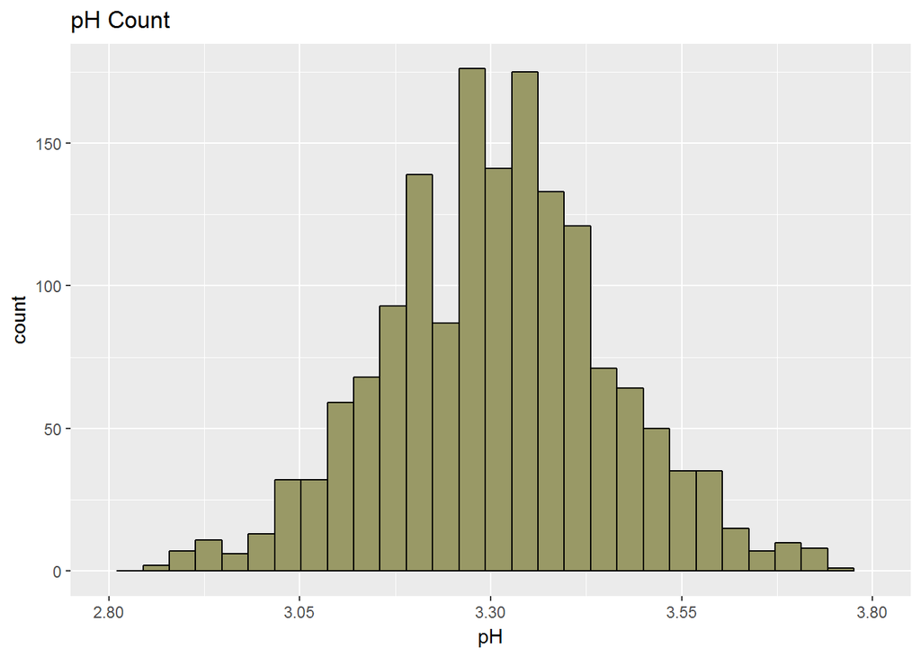

```r
ggplot(aes(x=pH),data=pr)+
  geom_histogram(color=I('black'),fill=I('#999966'))+
  scale_x_continuous(limits=c(2.80,3.80),breaks=seq(2.80,3.80,0.25))+
  xlab('pH')+
  ggtitle('pH Count')
```

pH is a normal histogram plot that has a Median of 3.310 and Mean of 3.311.

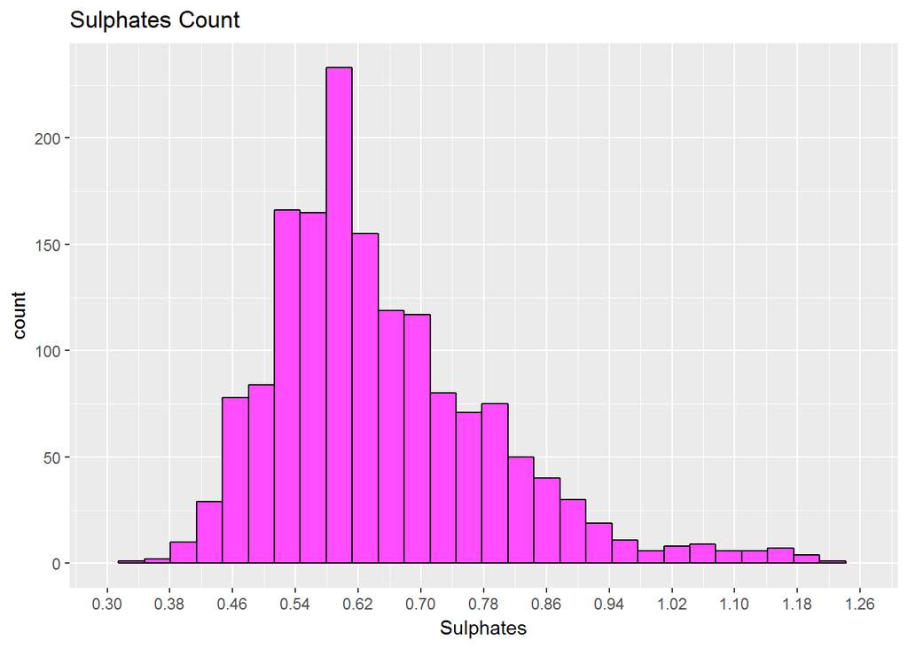

```r
ggplot(aes(x=sulphates),data=pr)+
  geom_histogram(color=I('black'),fill=I('#ff4dff'))+
  scale_x_continuous(limits=c(0.3,1.26),breaks=seq(0.3,1.26,0.08))+
  xlab('Sulphates')+
  ggtitle('Sulphates Count')
```

Sulphates have a Median of 0.6200 and Mean of 0.6581.

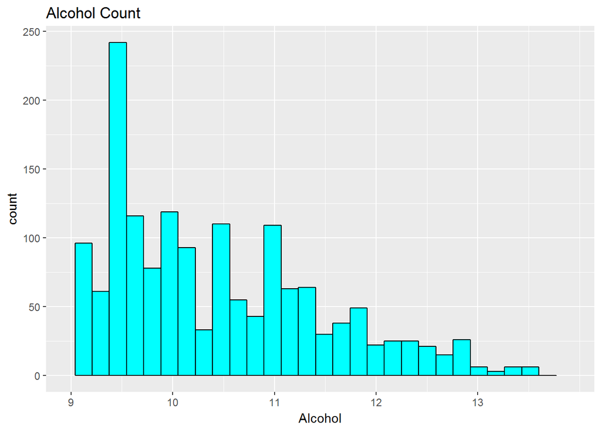

```r
ggplot(aes(x=alcohol),data=pr)+
  geom_histogram(color=I('black'),fill=I('#00ffff'))+
  scale_x_continuous(limits=c(9,13.9),breaks=seq(9,13.9,1))+
  xlab('Alcohol')+
  ggtitle('Alcohol Count')
```

Alcohol has a Median of 10.20 and Mean of 10.42.

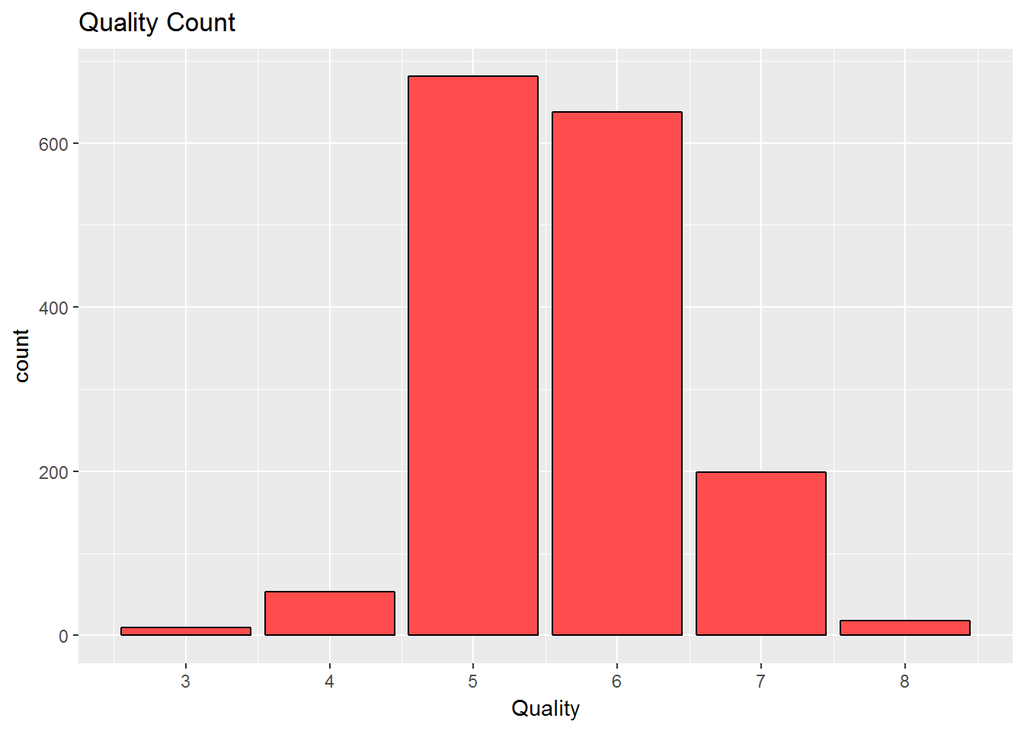

```r
ggplot(aes(x=quality),data=pr)+
  geom_bar(color=I('black'),fill=I('#ff4d4d'))+
  scale_x_continuous(breaks=seq(2,9,1))+
  xlab('Quality')+
  ggtitle('Quality Count')
```

Quality has a Median of 6.000 and Mean of 5.636.

# Univariate Analysis

# What is the structure of your dataset?

The red whine dataset contains 13 variables and 1599 observations. All the variables of num data type except X and quality variable.

# What is/are the main feature(s) of interest in your dataset?

Quality of the wine is the main focus here. The quality of the wine is dependent on the content of the alcohol, citric acid and sulphates in general. These variables make the quality of the wine from better to best. Also, if the volatile acidity variable content is high then we risk the quality of or wine.

# Did you create any new variables from existing variables in the dataset?

No I did not create any new variable from the existing variable.

# Did you perform any operations on the data to tidy, adjust, or change the formof the data? If so, why did you do this?

Yes, I log transformed the chlorides because they were were skewed and to get to bulk of data log transformation was performed.

# BIVARIATE PLOTS SECTION

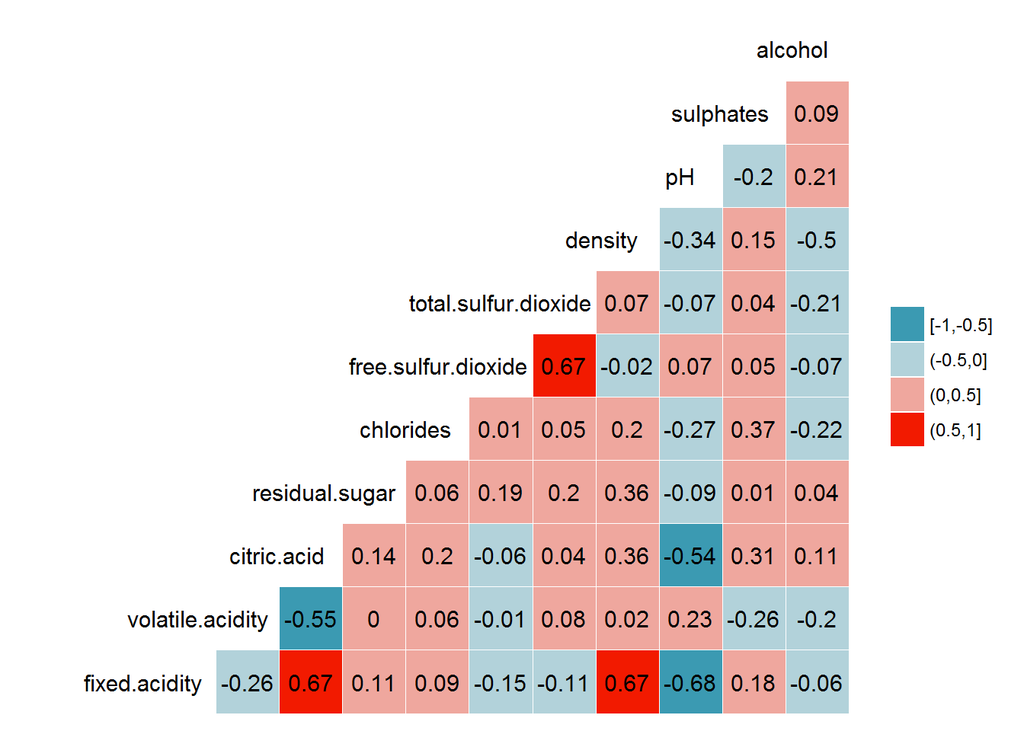

```r
pr1 <- select(pr,2,2:12)
ggcorr(pr1,label = TRUE,label_round=2,label_size=4,nbreaks=4,size=4,hjust=0.85,layout.exp=2)
```

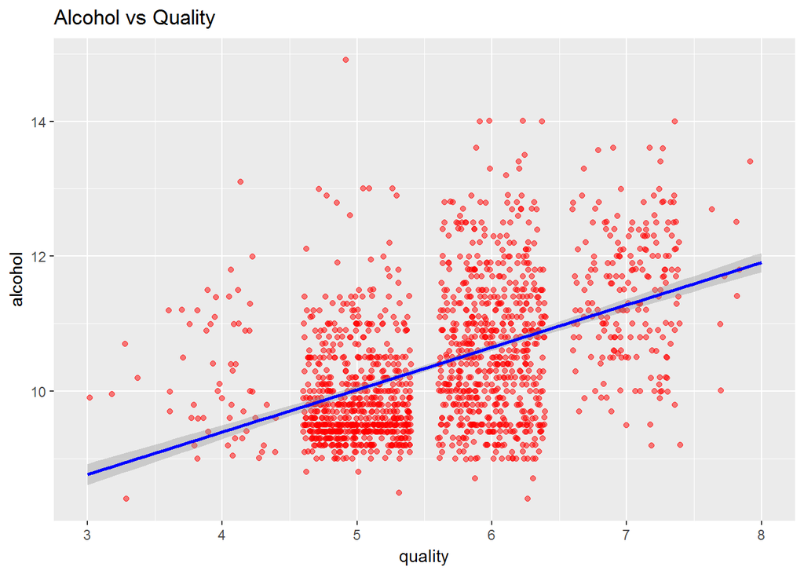

```r
ggplot(aes(x=quality,y=alcohol),data=pr)+
  geom_jitter(color=('red'),alpha=1/2)+
  scale_x_continuous(breaks=seq(3,8,1),limit=c(3,8))+
  geom_smooth(method='lm',color='blue')+
  ggtitle('Alcohol vs Quality')
```

In this plot of Alcohol vs Quality we see that alcohol shows a positive linear relationship with the quality of wine. Thus, proving that high content alcohol gives us a high quality wine.

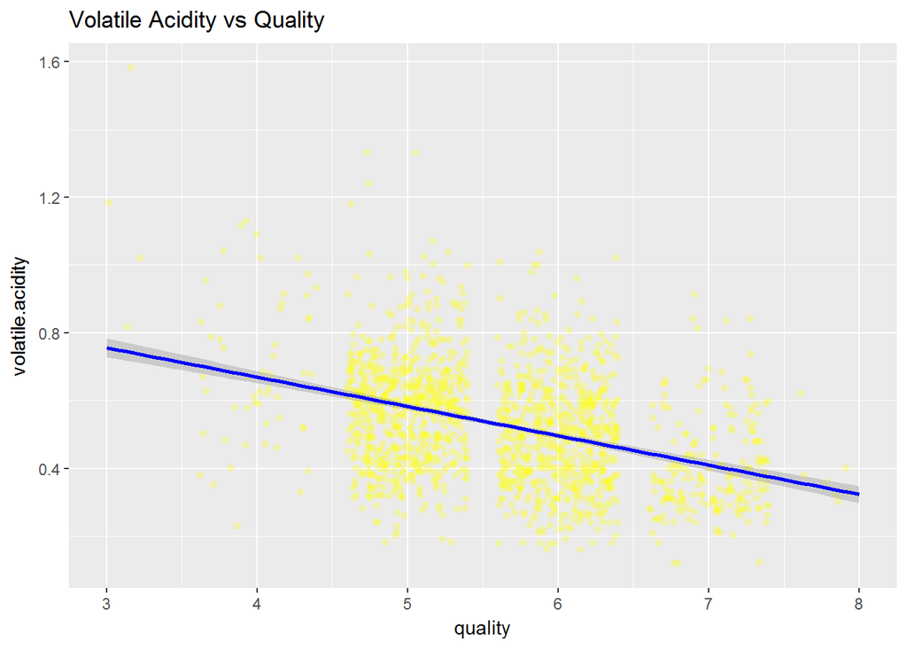

```r
ggplot(aes(x=quality,y=volatile.acidity),data=pr)+
  geom_jitter(color=('yellow'),alpha=1/4)+
  scale_x_continuous(breaks=seq(3,8,1),limit=c(3,8))+
  geom_smooth(method='lm',color='blue')+
  ggtitle('Volatile Acidity vs Quality')
```

In this plot of Volatile Acidity vs Quality we see that Volatile Acidity shows a negative linear relationship with the quality of wine. Thus, proving that low content volatile acid gives us a high quality wine.

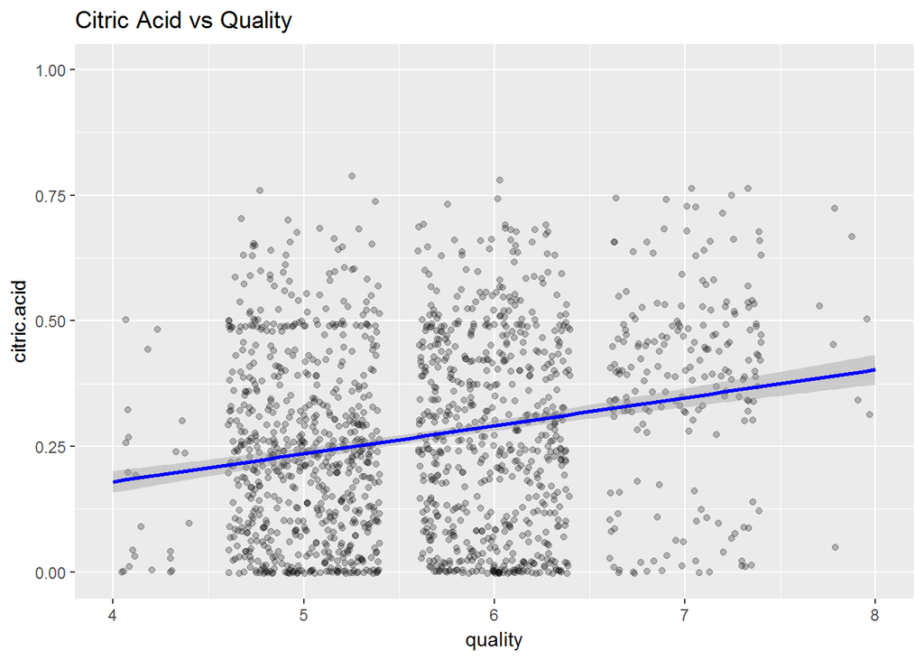

```r
ggplot(aes(x=quality,y=citric.acid),data=pr)+
  geom_jitter(color=('black'),alpha=1/4)+
  scale_x_continuous(breaks=seq(4,8,1),limit=c(4,8))+
  geom_smooth(method='lm',color='blue')+
  ggtitle('Citric Acid vs Quality')
```

In this plot of Citric Acid vs Quality we see that citric acid shows a positive linear relationship with the quality of wine. Thus, proving that high content citric acid gives us a high quality wine.

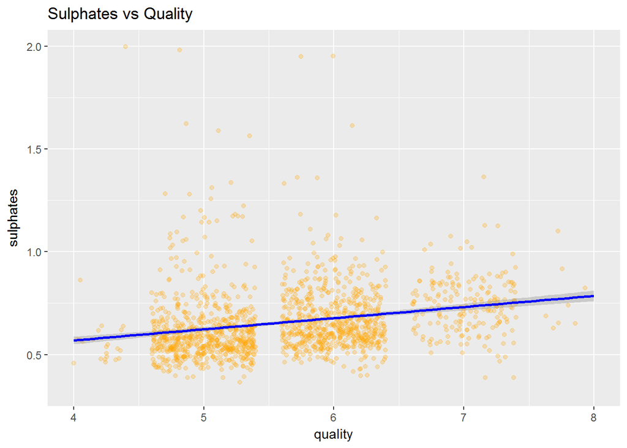

```r
ggplot(aes(x=quality,y=sulphates),data=pr)+
  geom_jitter(color=('orange'),alpha=1/4)+
  scale_x_continuous(breaks=seq(4,8,1),limit=c(4,8))+
  geom_smooth(method='lm',color='blue')+
  ggtitle('Sulphates vs Quality')
```

In this plot of Sulphates vs Quality we see that sulphates shows a positive linear relationship with the quality of wine. Thus, proving that high content sulphates gives us a high quality wine.

```r
set.seed(1599)
View(pr)
pr_subset <- pr[,c(1:12)]
cor(pr_subset[, c(1:11)])
```

```
##                                 X fixed.acidity volatile.acidity
## X                     1.000000000   -0.26848392     -0.008815099
## fixed.acidity        -0.268483920    1.00000000     -0.256130895
## volatile.acidity     -0.008815099   -0.25613089      1.000000000
## citric.acid          -0.153551355    0.67170343     -0.552495685
## residual.sugar       -0.031260835    0.11477672      0.001917882
## chlorides            -0.119868519    0.09370519      0.061297772
## free.sulfur.dioxide   0.090479643   -0.15379419     -0.010503827
## total.sulfur.dioxide -0.117849669   -0.11318144      0.076470005
## density              -0.368372087    0.66804729      0.022026232
## pH                    0.136005328   -0.68297819      0.234937294
## sulphates            -0.125306999    0.18300566     -0.260986685
##                      citric.acid residual.sugar    chlorides
## X                    -0.15355136   -0.031260835 -0.119868519
## fixed.acidity         0.67170343    0.114776724  0.093705186
## volatile.acidity     -0.55249568    0.001917882  0.061297772
## citric.acid           1.00000000    0.143577162  0.203822914
## residual.sugar        0.14357716    1.000000000  0.055609535
## chlorides             0.20382291    0.055609535  1.000000000
## free.sulfur.dioxide  -0.06097813    0.187048995  0.005562147
## total.sulfur.dioxide  0.03553302    0.203027882  0.047400468
## density               0.36494718    0.355283371  0.200632327
## pH                   -0.54190414   -0.085652422 -0.265026131
## sulphates             0.31277004    0.005527121  0.371260481
##                      free.sulfur.dioxide total.sulfur.dioxide     density
## X                            0.090479643          -0.11784967 -0.36837209
## fixed.acidity               -0.153794193          -0.11318144  0.66804729
## volatile.acidity            -0.010503827           0.07647000  0.02202623
## citric.acid                 -0.060978129           0.03553302  0.36494718
## residual.sugar               0.187048995           0.20302788  0.35528337
## chlorides                    0.005562147           0.04740047  0.20063233
## free.sulfur.dioxide          1.000000000           0.66766645 -0.02194583
## total.sulfur.dioxide         0.667666450           1.00000000  0.07126948
## density                     -0.021945831           0.07126948  1.00000000
## pH                           0.070377499          -0.06649456 -0.34169933
## sulphates                    0.051657572           0.04294684  0.14850641
##                               pH    sulphates
## X                     0.13600533 -0.125306999
## fixed.acidity        -0.68297819  0.183005664
## volatile.acidity      0.23493729 -0.260986685
## citric.acid          -0.54190414  0.312770044
## residual.sugar       -0.08565242  0.005527121
## chlorides            -0.26502613  0.371260481
## free.sulfur.dioxide   0.07037750  0.051657572
## total.sulfur.dioxide -0.06649456  0.042946836
## density              -0.34169933  0.148506412
## pH                    1.00000000 -0.196647602
## sulphates            -0.19664760  1.000000000
```

Through this we get the correlation between all the variables with each other.

Now we take variables those have correlation value greater than 5,with either negatively or positively correlated variables. Thus we have 1)citric acid and fixed acidity with value 0.6717 2)density and fixed acidity with value 0.6680 3)pH and fixed acidity with value -0.6829 4)citric acid and volatile acidity with value -0.5524 5)total sulfur dioxide and free sulfur dioxide with value 0.6676

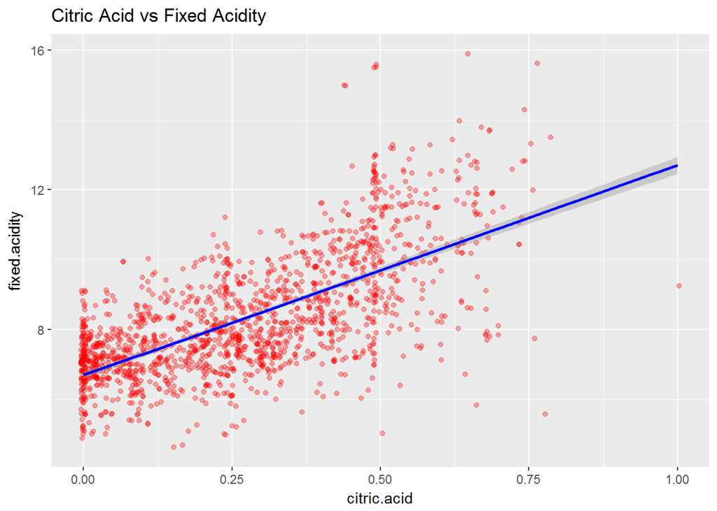

```r
ggplot(aes(x=citric.acid,y=fixed.acidity),data=pr)+
  geom_jitter(color=('red'),alpha=1/3)+
  geom_smooth(method='lm',color='blue')+
  ggtitle('Citric Acid vs Fixed Acidity')
```

This plot of Citric Acid vs Fixed Acidity indicates that the correlation between the two variables is very strong i.e. 0.6717 and has a positive linear relationship.

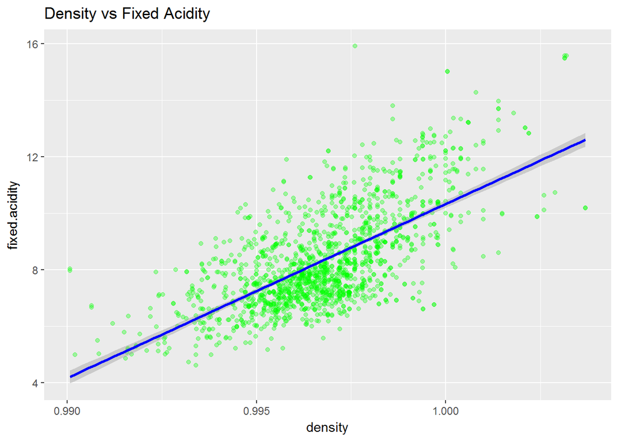

```r
ggplot(aes(x=density,y=fixed.acidity),data=pr)+
  geom_jitter(color=('green'),alpha=1/3)+
  geom_smooth(method='lm',color='blue')+
  ggtitle('Density vs Fixed Acidity')
```

This plot of Density vs Fixed Acidity indicates that the correlation between the two variables is very strong i.e. 0.6680 and has a positive linear relationship.

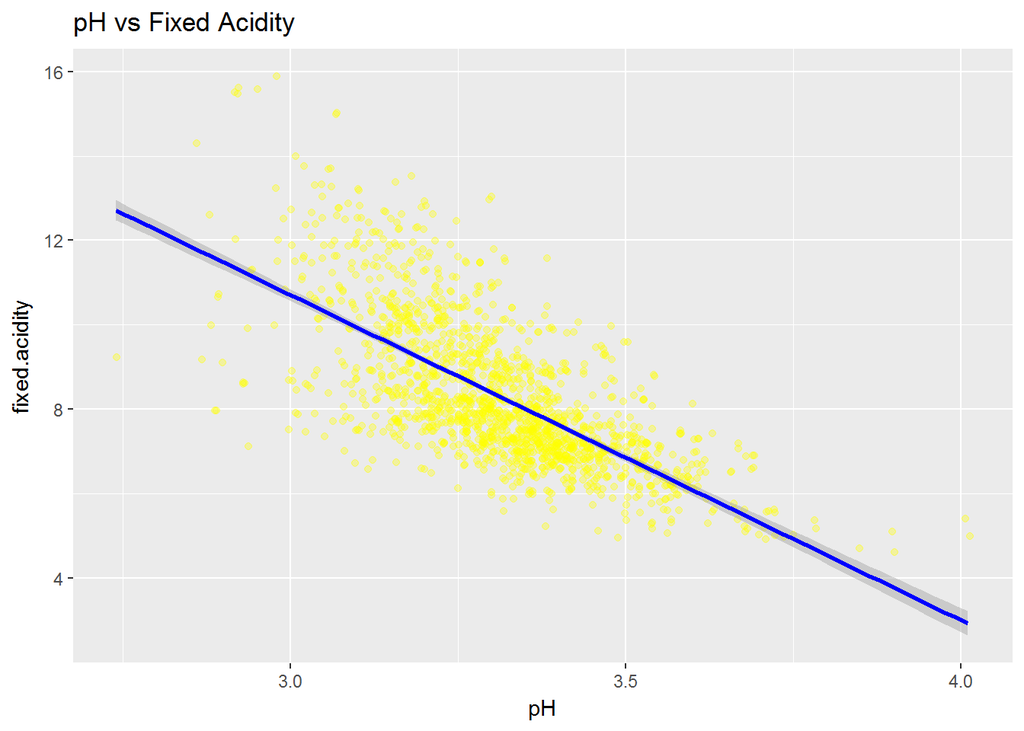

```r
ggplot(aes(x=pH,y=fixed.acidity),data=pr)+
  geom_jitter(color=('yellow'),alpha=1/3)+
  geom_smooth(method='lm',color='blue')+
  ggtitle('pH vs Fixed Acidity')
```

This plot of pH vs Fixed Acidity indicates that the correlation between the two variables is very strong i.e. -0.6829 and has a negative linear relationship.

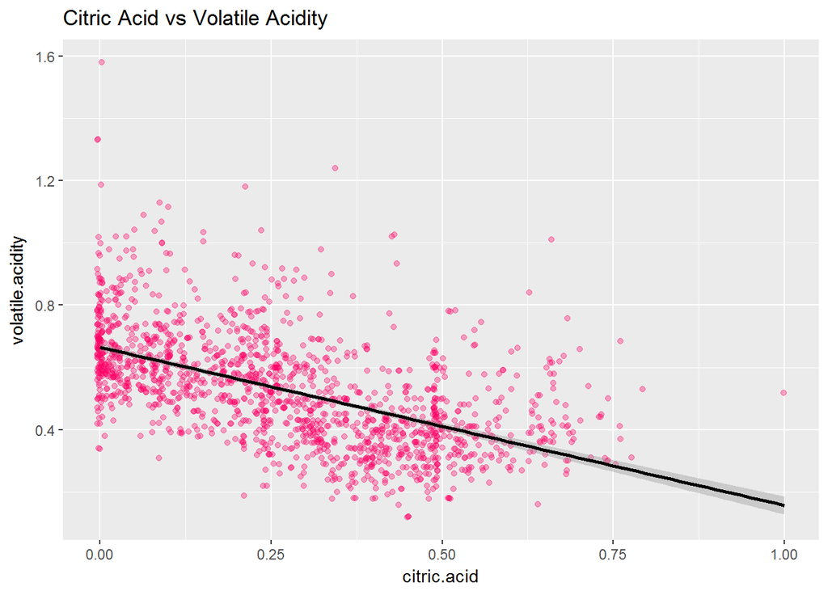

```r
ggplot(aes(x=citric.acid,y=volatile.acidity),data=pr)+
  geom_jitter(color=('#ff0066'),alpha=1/3)+
  geom_smooth(method='lm',color='black')+
  ggtitle('Citric Acid vs Volatile Acidity')
```

This plot of Citric Acid vs Volatile Acidity indicates that the correlation between the two variables is very strong i.e. -0.5524 and has a negative linear relationship.

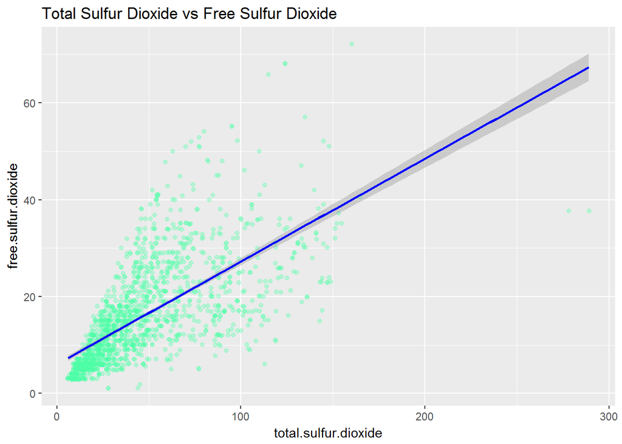

```r
ggplot(aes(x=total.sulfur.dioxide,y=free.sulfur.dioxide),data=pr)+
  geom_jitter(color=('#4dffa6'),alpha=1/3)+
  geom_smooth(method='lm',color='blue')+
  ggtitle('Total Sulfur Dioxide vs Free Sulfur Dioxide')
```

This plot of Total Sulfur Dioxide vs Free Sulfur Dioxide indicates that the correlation between the two variables is very strong i.e. 0.6676 and has a positive linear relationship.

# Bivariate Analysis

# Talk about some of the relationships you observed in this part of the investigation. How did the feature(s) of interest vary with other features in the dataset?

The histograms of variables with respect to quality did not reveal much information except that alcohol strongly affects wine quality.Through correlation test we created scatterplots that showed strong positive and negativecorrelation of variable with other. Alcohol is the positive correlation variable where as volatile acidity is the negative correlation variable. Therefore, we gather that when the quantity of variables like alcohol, citric acid and sulphates are high then the wine quality becomes high as well. And when the quantity of volatile acidity is low then also our quality of wine becomes high.

# Did you observe any interesting relationships between the other features (not the main feature(s) of interest)?

While using correlation to test the correlation between variables with each other we get that 1)citric acid and fixed acidity with value 0.6717 2)density and fixed acidity with value 0.6680 3)pH and fixed acidity with value -0.6829 4)citric acid and volatile acidity with value -0.5524 5)total sulfur dioxide and free sulfur dioxide with value 0.6676

# What was the strongest relationship you found?

Throug correlation we found that citric acid and fixed acidity show us a strong positive correlation of 0.6717 whereas pH and fixed acidity show a strong negative correlation -0.6829

# MULTIVARIATE PLOT SECTION

```r
names(pr$quality)
```

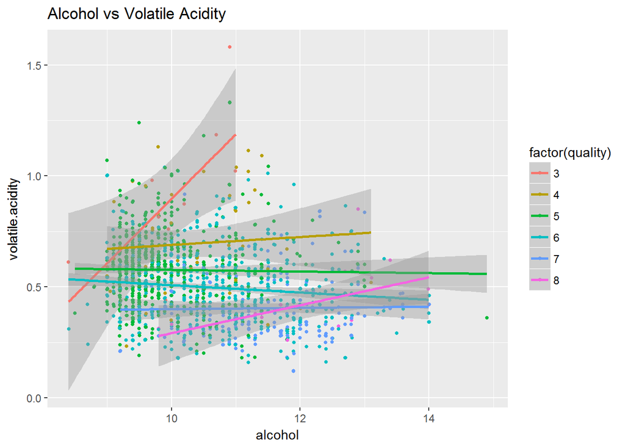

```r
ggplot(data=pr,aes(x=alcohol,y=volatile.acidity,color=factor(quality)))+
  geom_jitter(size = 1) +
  geom_smooth(method='lm')+
  ggtitle('Alcohol vs Volatile Acidity')
```

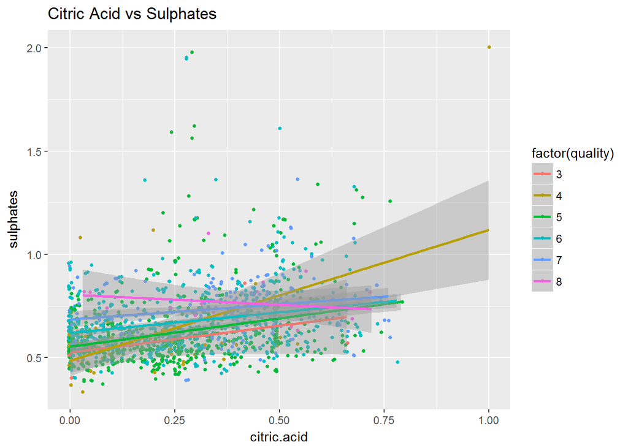

```r
ggplot(data=pr,aes(x=citric.acid,y=sulphates,color=factor(quality)))+
  geom_jitter(size = 1) +
  geom_smooth(method='lm')+
  ggtitle('Citric Acid vs Sulphates')
```

Sulphates and citric acid are the next two most correlated variables with quality. This plot is not quite a clear as the previous one. It appears that wine improves in quality with more sulphates.

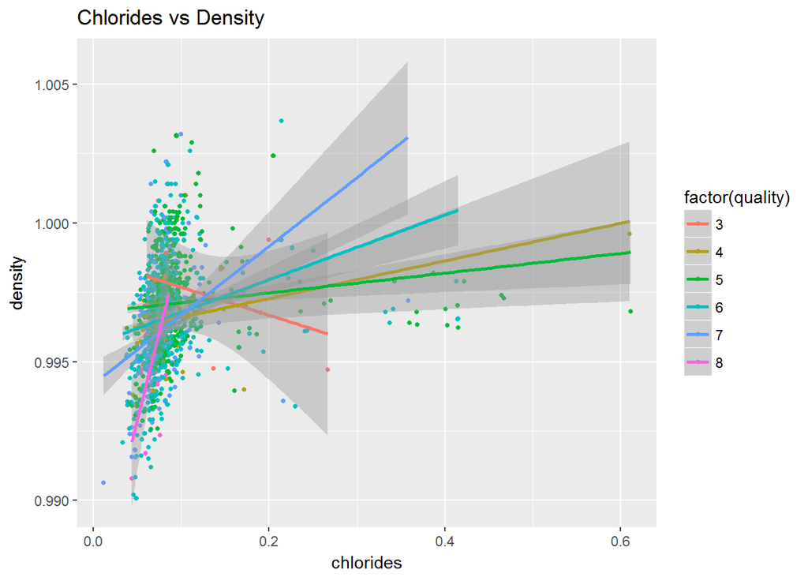

```r
ggplot(data=pr,aes(x=chlorides,y=density,color=factor(quality)))+
  geom_jitter(size = 1) +
  geom_smooth(method='lm')+
  ggtitle('Chlorides vs Density')
```

Chlorides and density have the weakest correlations with quality. But it appears that wine is best when it is less dense and has fewer chlorides.

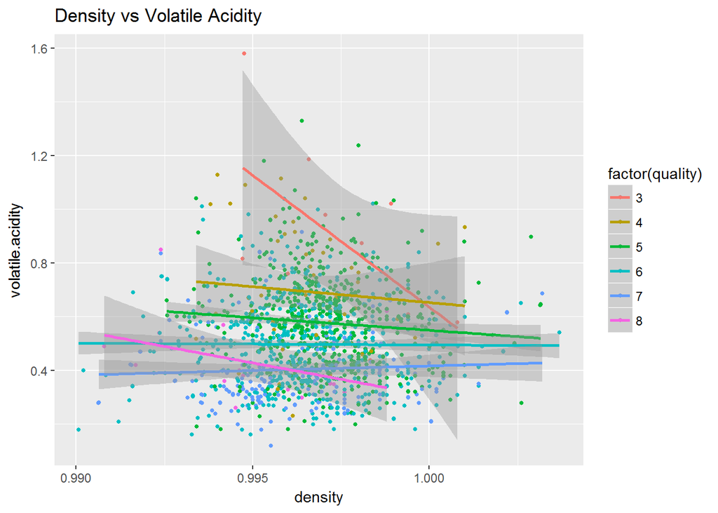

```r
ggplot(aes(y=volatile.acidity,x=density,color=factor(quality)),data=pr)+
  geom_jitter(size = 1) +
  geom_smooth(method='lm')+
  ggtitle('Density vs Volatile Acidity')
```

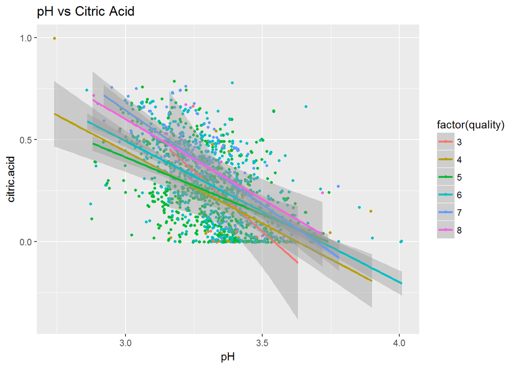

```r
ggplot(aes(y=citric.acid,x=pH,color=factor(quality)),data=pr)+
  geom_jitter(size = 1) +
  geom_smooth(method='lm')+
  ggtitle('pH vs Citric Acid')
```